# Simulation Study - Casarin

Alessandro Colombi

27/1/2023

# 00 - Empirical Bayes

We use an Empirical Bayes strategy to choose $P_0$ hyperparameters $(\mu_0,\kappa_0,\nu_0,\sigma^2_0)$. Let $\hat{y}_n$ be the sample mean of all data points and let $\hat{s}^2_n$ be their variance.

The strategy we proposed requires 3 additional parameters to be specified

- $\bar{\text{V}}_\mu$: a priori variance for $\mu$
- $\bar{\text{V}}_{\sigma^2}$: a priori variance for $\sigma^2$
- $\text{c}$: extra parameter I can not interpret

$$\text{E}[\mu] = \hat{y}_n \\
\text{Var}(\mu) = \bar{\text{V}}_\mu \\
\text{E}[\sigma^2] = \hat{s}^2_n / \text{c}\\
\text{Var}[\sigma^2] = \bar{\text{V}}_{\sigma^2}$$

# 0 - Osservazioni

- Le medie a posteriori sono

$$\mu_k \mid \sigma^2,X_1,\dots,X_n \sim
\text{N}\left(\frac{n_k}{n_k + k_0}\bar{X_k} + \frac{k_0}{n_k +
k_0}\mu_0, \frac{\sigma^2}{k_0 + n_k} \right)$$

$$\sigma^2_k \mid X_1,\dots,X_n \sim
\text{InvGamma}\left(\frac{\nu_0 + n_k}{2}, \frac{1}{2}(\nu_0\sigma_0^2
+ (n_k-1)V_k + \frac{n_k k_0}{n_k + k_0}(\bar{X}_k -
\mu_0)^2)\right)$$

dove $n_k$ è la numerosità, $\bar{X}_k$ è la media campionaria e $V_k$ è la varianza campionaria del cluster $k$.

- Con valori di $k_0$ alti, il peso legato alla prior nella media a posteriori è molto simile a quello dato all’evidenza dei dati $\frac{n_k}{n_k + k_0} \approx \frac{k_0}{n_k + k_0}$.
- Quindi, dalla media a posteriori mi viene da dire che sarebbe meglio avere $k_0$ basso in modo da avere la media a posteriori guidata dalla media nel cluster.
  - In Empirical Bayes mettiamo $k_0 = \frac{\bar{\sigma^2}}{\bar{V_\mu}}$, quindi è meglio aumentare $\bar{V_\mu}$.
  - Bello che $k_0$ sia l’unico valore a dipendere da $\bar{V_{\mu}}$, quindi posso regolarlo direttamente.
- Per la varianza, non voglio $\nu_0\sigma^2_0$ troppo alto altrimenti conta solo la parte dalla prior
  - Per contenere $\nu_0$ posso aumentare $\bar{V_\sigma}$, ha anche un po’ di impatto su $\sigma_0^2$.
  - Per ridurre tutto, si può lavorare anche sul parametro di correzione: per fare matching dei momenti, metto $E[\sigma^2] = \bar{\sigma^2}/correction$. Seguendo il lavoro di Raf avevo sempre considerato $correction = 3$ ma penso sia meglio alzarlo.

# 1 - Reference example

**Dati esperimento:**

- **K = 3**
- d = 3
- $n_1 = 100$, $n_2 = 50$, $n_3 = 50$
- $\mu_1 = -5$, $\mu_2 = 0$, $\mu_3 = 5$
- $\sigma_1 = \sigma_2 = \sigma_3 = 1$
- $\pi_{11} = 3/10, \pi_{12} = 3/10, \pi_{13} = 4/10$
- $\pi_{21} = 3/10, \pi_{22} = 7/10, \pi_{23} = 0$
- $\pi_{31} = 8/10, \pi_{32} = 1/10, \pi_{33} = 1/10$

## Data Generation

```r
suppressWarnings(suppressPackageStartupMessages(library(GDFMM)))
suppressWarnings(suppressPackageStartupMessages(library(ACutils)))
suppressWarnings(suppressPackageStartupMessages(library(tidyverse)))
suppressWarnings(suppressPackageStartupMessages(library(RColorBrewer)))
suppressWarnings(suppressPackageStartupMessages(library(salso)))
suppressWarnings(suppressPackageStartupMessages(library(wesanderson)))
suppressWarnings(suppressPackageStartupMessages(library(mcclust.ext)))
```

```r
mycol = hcl.colors(n=3,palette = "Zissou1")

d = 3                   # number of groups
K = 3                   # number of global clusters
mu = c(-5,0,5)          # vectors of means
sd = c(1,1,1)           # vector of sd
n_j = c(100,50,50)      # set cardinality of the groups

mix_probs = matrix(c(3/10,3/10,4/10,
                     3/10,7/10,   0,
                     8/10,1/10,1/10), nrow = d, ncol = K, byrow = T)
seed = 200532121

genD = simulate_data(d = d, K = K, p = mix_probs, mu = mu, sd = sd, n_j = n_j, seed = seed)
data = genD$data
real_partition = genD$real_partition

mycol_cluster = brewer.pal(n=K, name = "Dark2")
```

## Data Visualization

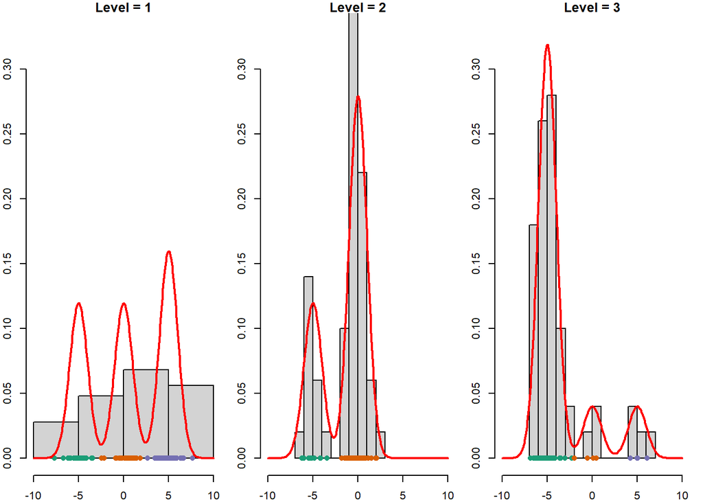

```r
idx_start = 1
idx_end = n_j[1]
xrange = c(-10,10)
l_grid = 200
grid = seq(xrange[1],xrange[2],length.out = l_grid)


par(mfrow = c(1,d), mar = c(2,2,1,1), bty = "l")
for(j in 1:d){
  mycol_cluster = brewer.pal(n=K, name = "Dark2")
  mycol_points  = as.factor(real_partition[idx_start:idx_end])
  levels(mycol_points) = unique(mycol_cluster)
  mycol_points = as.character(mycol_points)

  #dj = density(data[j,1:n_j[j]])

  hist(data[j,1:n_j[j]], freq = F, main = paste0("Level = ",j),
       xlim = xrange, ylim = c(0,0.33),
       nclass = "fd")

  points( x = data[j,1:n_j[j]], y = rep(0,n_j[j]),
          pch = 16, col = mycol_points)
  #lines(dj$x,dj$y, lwd = 2)
  points(grid, GDFMM::dmix(x = grid, w_j = mix_probs[j,], mu_vec = mu, sigma_vec = sd),
         col = "red", lwd = 2, type = "l")

  idx_start = idx_end + 1
  if(j<d){
    idx_end = idx_end + n_j[j+1]
  }
}
```

## Iperparametri $P_0$

```r
# Calcolo anche la marginale trovata con i valori di Empirical Bayes e la plotto sopra
varsig2 = 100 * var(as.vector(data), na.rm = T)^2
P0_hyparam = empirical_bayes_normalinvgamma(data = data, varmu = 100, varsig2 = varsig2, correction = 100)
mu0 = P0_hyparam$mu0
k0= P0_hyparam$k0
nu0=P0_hyparam$nu0
sigma0=P0_hyparam$sigma0

c("mu0"=mu0,"k0"=k0,"nu0"=nu0,"sigma0"=sigma0)
```

```
#>          mu0           k0          nu0       sigma0
#> -0.761141824  0.001750133  4.000002000  0.087506701
```

```r
scale = sqrt( (k0 + 1)/(k0) * sigma0 )
mean_marginal = mu0
var_marginal  = nu0/(nu0-2) * scale^2

mean_marginal
```

```
#> [1] -0.7611418
```

```r
var_marginal
```

```
#> [1] 100.175
```

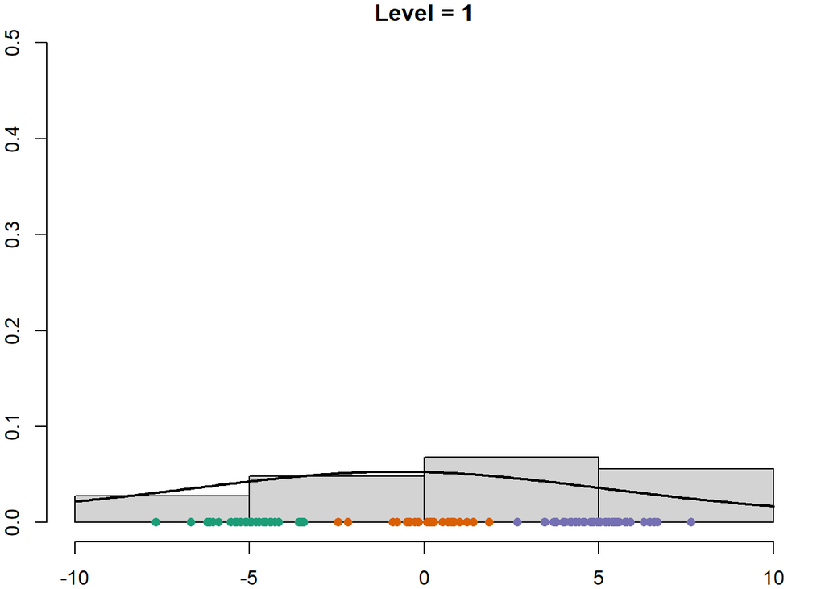

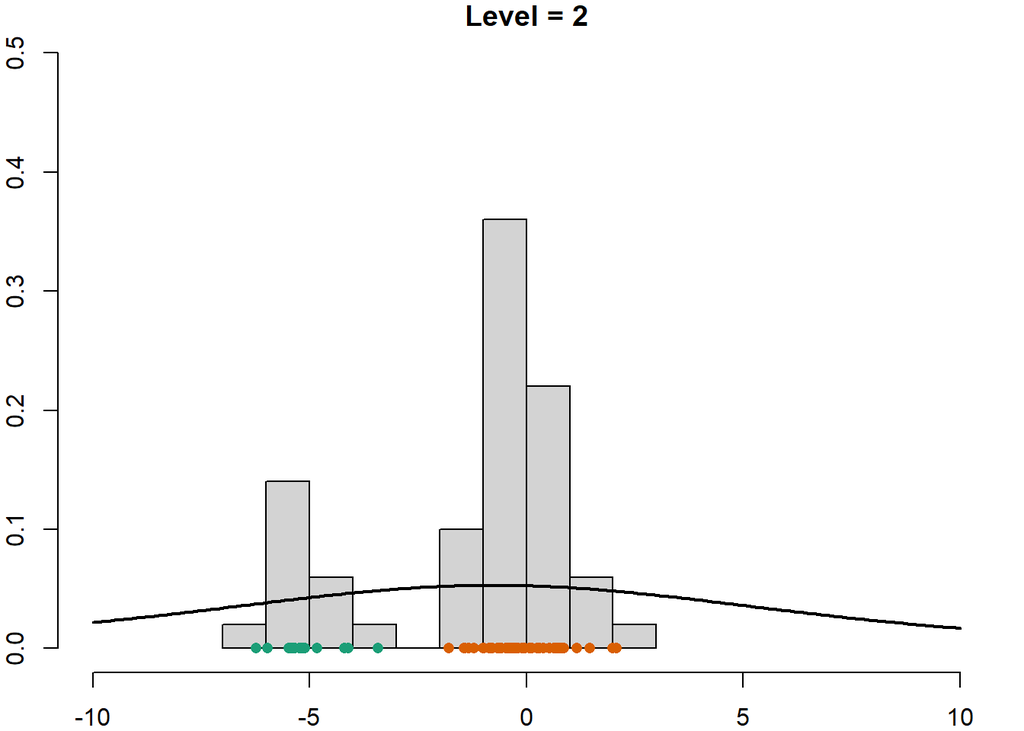

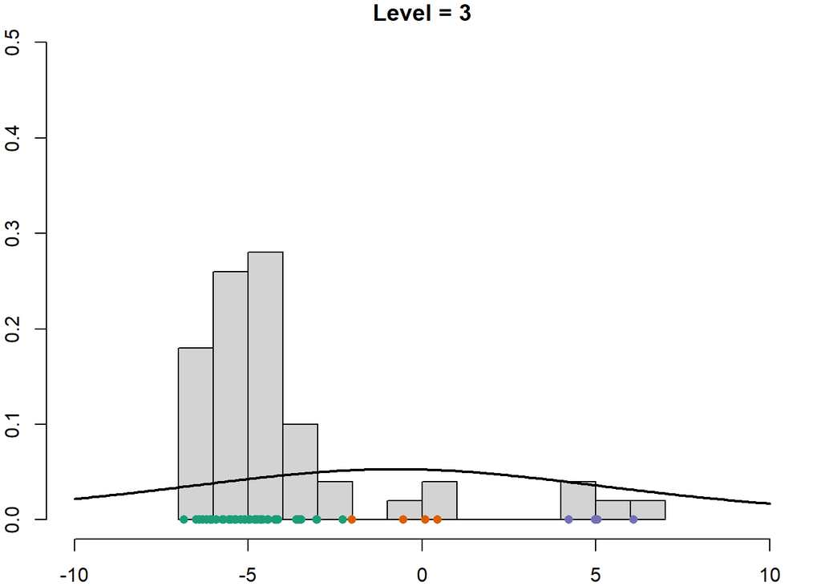

```r
xrange = c(-10,10)
l_grid = 200
grid = seq(xrange[1],xrange[2],length.out = l_grid)
# In questo plot sotto colori i pallini secondo il vero cluster.
idx_start = 1
idx_end = n_j[1]

Prior_grid = GDFMM:::dnct(x = grid, n0 = nu0, mu0 = mu0, gamma0 = scale)

for(j in 1:d){
  mycol_cluster = brewer.pal(n=K, name = "Dark2")
  mycol_points  = as.factor(real_partition[idx_start:idx_end])
  levels(mycol_points) = unique(mycol_cluster)
  mycol_points = as.character(mycol_points)

  par(mar = c(2,2,1,1), bty = "l")
  hist(data[j,1:n_j[j]], freq = F, main = paste0("Level = ",j),
       xlim = xrange, ylim = c(0,0.5),
       nclass = "fd")

  points( x = data[j,1:n_j[j]], y = rep(0,n_j[j]),
          pch = 16, col = mycol_points)
  points(grid, Prior_grid, col = "black", lwd = 2, type = "l")


  idx_start = idx_end + 1
  if(j<d){
    idx_end = idx_end + n_j[j+1]
  }
}
```

### Marginali nei cluster

Fissato il valore degli iperparametri, voglio visualizzare non solo la marginale dei dati ma anche le marginali nei cluster

Calcolo media e varianza nei cluster

```r
counter = 1
data_per_cluster = vector("list", length = K)
log_marginal_prior = vector("list", length = d)
for(j in 1:d){
  log_marginal_prior[[j]] = vector( length = n_j[j])
  for(i in 1:n_j[j]){
    c_ji = real_partition[counter]
    data_per_cluster[[c_ji]] = c(data_per_cluster[[c_ji]], data[j,i])
    log_marginal_prior[[j]][i] = log(ACutils::dnct(data[j,i], n0 = 10, mu0 = 1, gamma0 = sqrt(2)) )
    counter = counter + 1
  }

}
#data_per_cluster
mean_data_per_cluster = unlist(lapply(data_per_cluster, mean))
mean_data_per_cluster
```

```
#> [1] -5.02845382 -0.05042807  5.06602118
```

```r
var_data_per_cluster  = unlist(lapply(data_per_cluster, var))
var_data_per_cluster
```

```
#> [1] 0.9719977 0.9180346 1.0216515
```

```r
ndata_per_cluster = unlist(lapply(data_per_cluster, length))
ndata_per_cluster
```

```
#> [1] 82 66 52
```

```r
#log_marginal_prior
```

```r
dof_post = nu0 + ndata_per_cluster
k0_post  = k0 + ndata_per_cluster
location_post = (k0*mu0 + mean_data_per_cluster*ndata_per_cluster)/(k0 + ndata_per_cluster)
sigma0_post   = 1/dof_post*( (ndata_per_cluster - 1)*var_data_per_cluster +
                              nu0*sigma0 +
                              (k0*ndata_per_cluster)/(k0 + ndata_per_cluster) * (mu0 - mean_data_per_cluster)^2
                           )

scale_post = sqrt( (sigma0_post*(k0_post + 1))/(k0_post)  )

mean_marginal_per_cluster = location_post
var_marginal_per_cluster = scale_post^2 * (dof_post)/(dof_post - 2)

mean_marginal_per_cluster
```

```
#> [1] -5.02836275 -0.05044692  5.06582507
```

```r
var_marginal_per_cluster
```

```
#> [1] 0.9533153 0.8960673 0.9911764
```

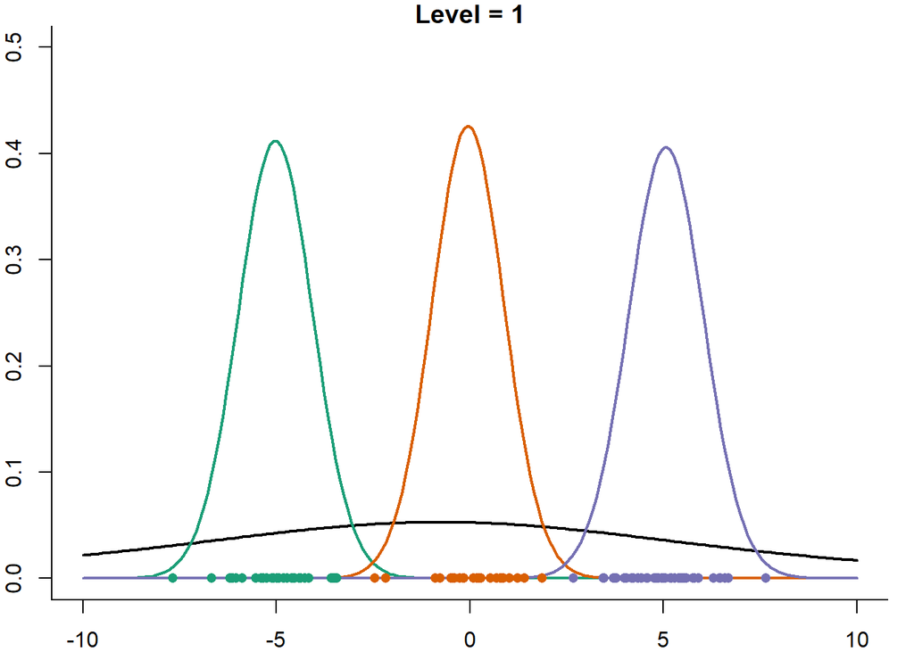

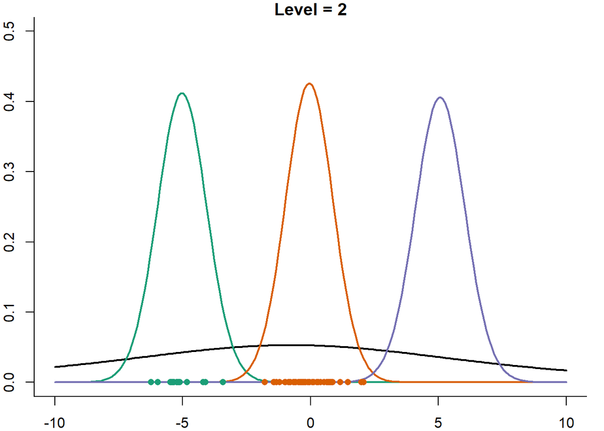

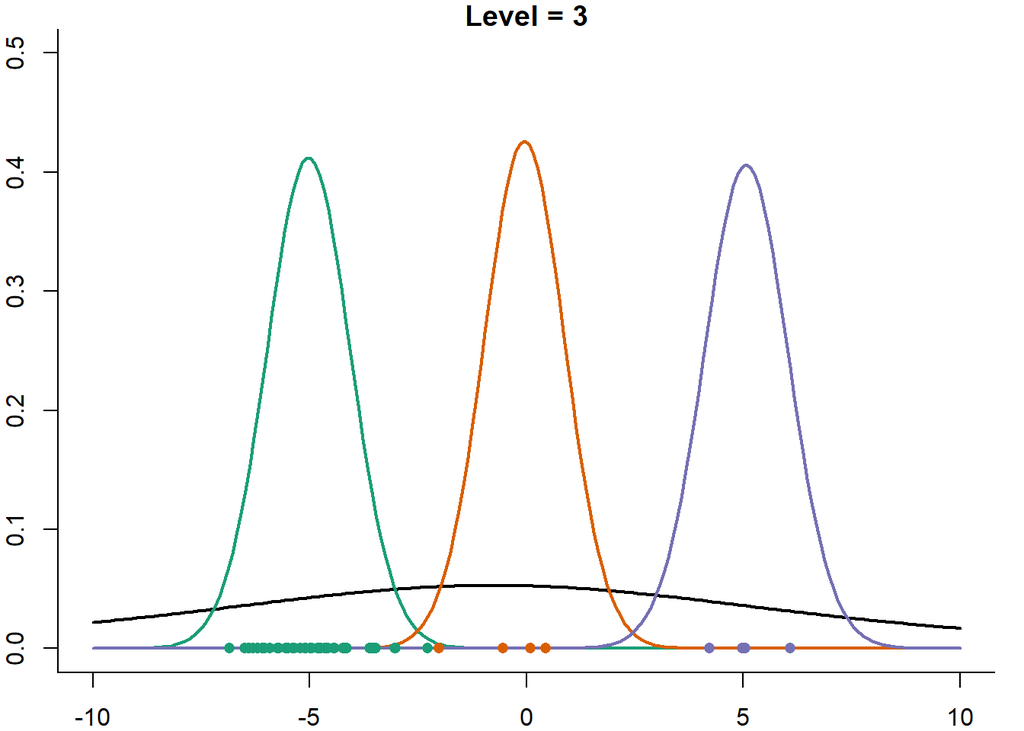

```r
xrange = c(-10,10)
l_grid = 200
grid = seq(xrange[1],xrange[2],length.out = l_grid)
idx_start = 1
idx_end = n_j[1]

Prior_grid = GDFMM:::dnct(x = grid, n0 = nu0, mu0 = mu0, gamma0 = scale)



for(j in 1:d){
  mycol_cluster = brewer.pal(n=K, name = "Dark2")
  mycol_points  = as.factor(real_partition[idx_start:idx_end])
  levels(mycol_points) = unique(mycol_cluster)
  mycol_points = as.character(mycol_points)

  par(mar = c(2,2,1,1), bty = "l")
  plot(grid, Prior_grid, col = "black", lwd = 2, type = "l",
          main = paste0("Level = ",j),
          xlim = xrange, ylim = c(0,0.5))

  for(kk in 1:K){
    Marginal_per_cluster_grid = GDFMM:::dnct(x = grid,
                                         n0 = dof_post[kk],
                                         mu0 = location_post[kk],
                                         gamma0 = scale_post[kk])

    points(grid, Marginal_per_cluster_grid, col = mycol_cluster[kk], lwd = 2, type = "l")

  }
  points( x = data[j,1:n_j[j]], y = rep(0,n_j[j]),
          pch = 16, col = mycol_points )

  idx_start = idx_end + 1
  if(j<d){
    idx_end = idx_end + n_j[j+1]
  }
}
```

## Run

```r
# Run  --------------------------------------------------------------------
niter  <-  10000
burnin <-  6000
thin   <-  1

# tau
a_gamma <-   1; b_gamma  <- 1
a_lambda <- 10; b_lambda <- 2

option = set_options_marginal(
             "mu0" = mu0,"sigma0"= sigma0, "k0"= k0, "nu0"=nu0,
             "Adapt_MH_hyp1"= 0.7,"Adapt_MH_hyp2"= 0.234,
             "sp_mala_U" = 0.01, "sp_mala_gamma"=0.01,
             "gamma0" = 3,"Lambda0" = 10,
             "alpha_gamma"=a_gamma, "beta_gamma"=b_gamma,
             "alpha_lambda"=a_lambda, "beta_lambda"=b_lambda,
             "init_mean_cluster" = NULL,#unlist(mean_data_per_cluster),
             "init_var_cluster" = NULL,#unlist(var_data_per_cluster),
             "UpdateU" = T, "UpdateGamma" = T, "UpdateTau" = T, "UpdateLambda" = T,
             "partition" = real_partition#seq(1,sum(n_j))
        )

# P0 Hyperparameters:
# old set: "mu0" = 0,"sigma0"= 1, "k0"= 1/10, "nu0"=10,
# new set: "mu0" = P0_hyparam$mu0, "k0"= P0_hyparam$k0, "nu0"=P0_hyparam$nu0, "sigma0"= P0_hyparam$sigma0,

# Process parameters
# old set:  "gamma0" = 1,"Lambda0" = 3,
#           "alpha_gamma"=5, "beta_gamma"=0.5, "alpha_lambda"=1, "beta_lambda"=5,


#GDFMM = GDFMM_sampler(data, niter, burnin, thin, seed = 123, option = option)
GDFMM = GDFMM_marginal_sampler(data, niter, burnin, thin, seed = 123, FixPartition = F, option = option)
```

```
#>
#>  Check that provided partition is well formed. It must start from 0 and all values must be contiguous
#> GibbsSamplerMarginal.cpp - Initialization
#> initialize_Partition with non empty partition_vec
#>  (K, Mstar, M) = (3,0,3)
#> DEVO CAMBIARE LA STRUTTURA DEI INPUT DEI DATI COME HA FATTO VEDERE BARTOLUCCI
```

### Chains

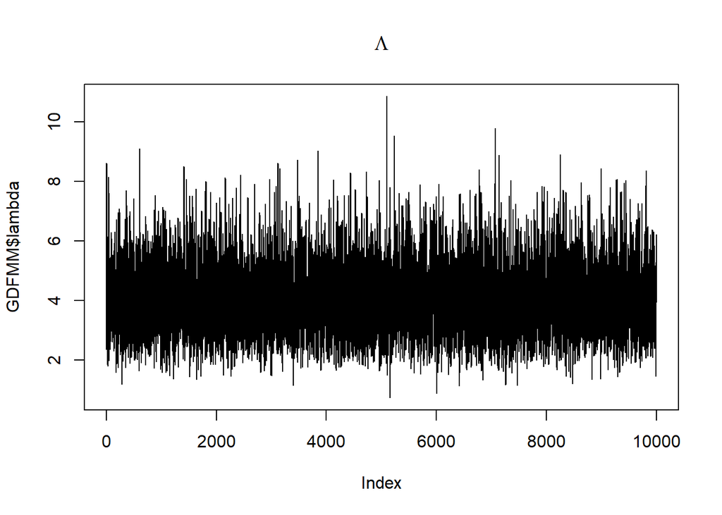

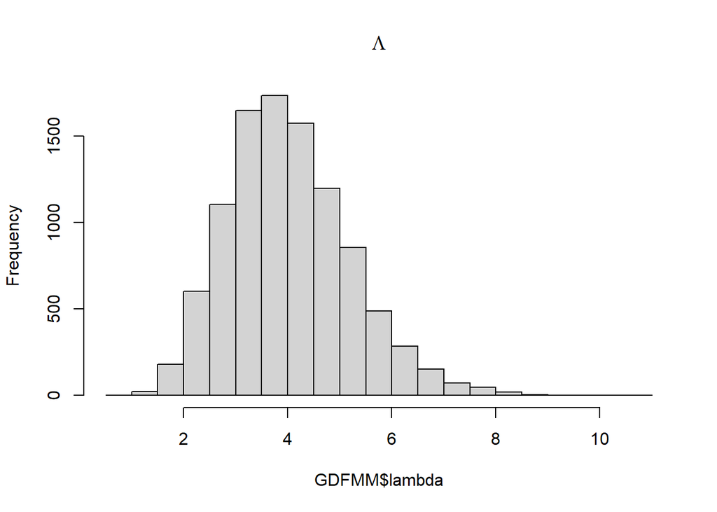

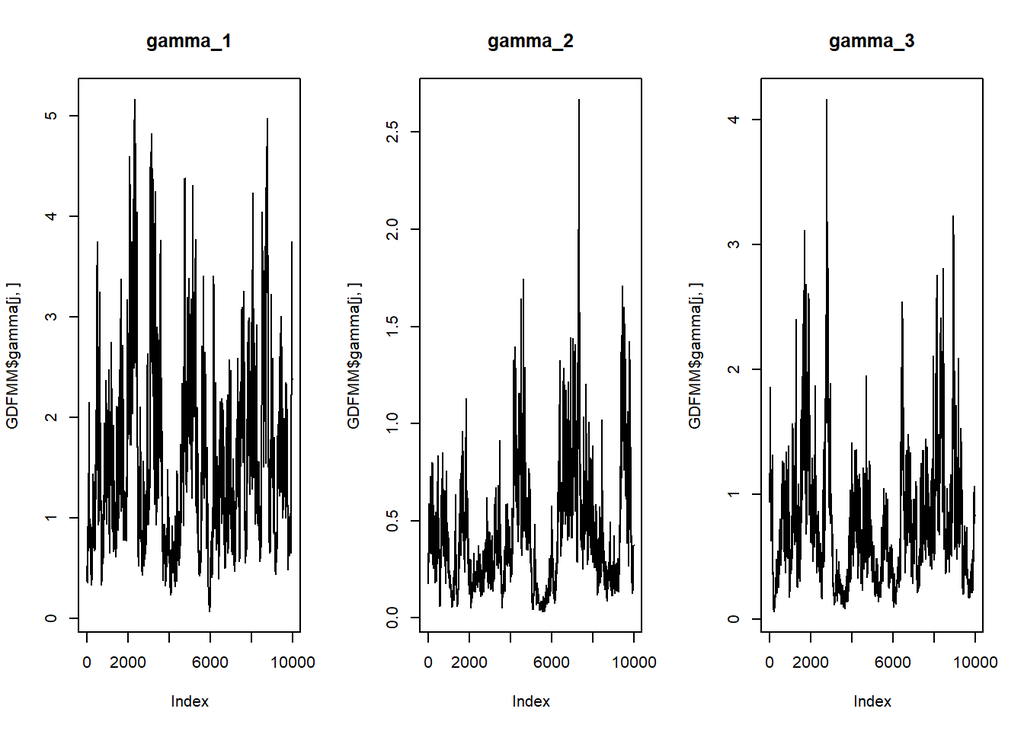

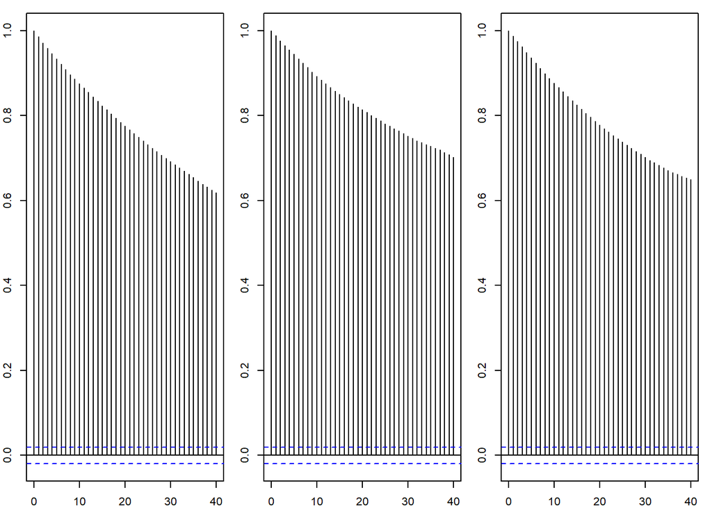

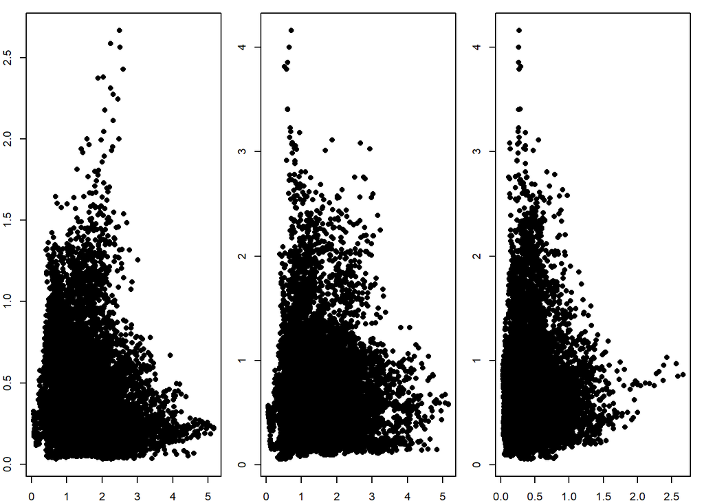

```
#> [1] -0.1323106
#> [1] -0.04738269
#> [1] 0.04388177
```

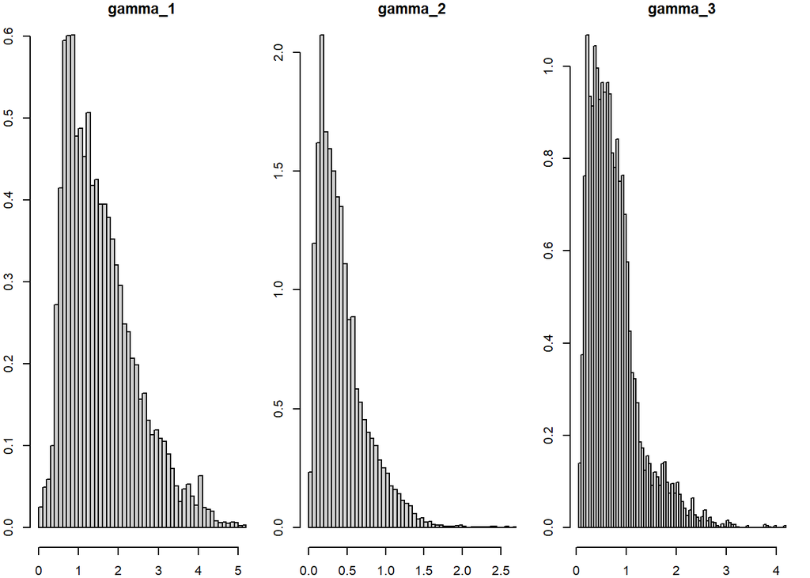

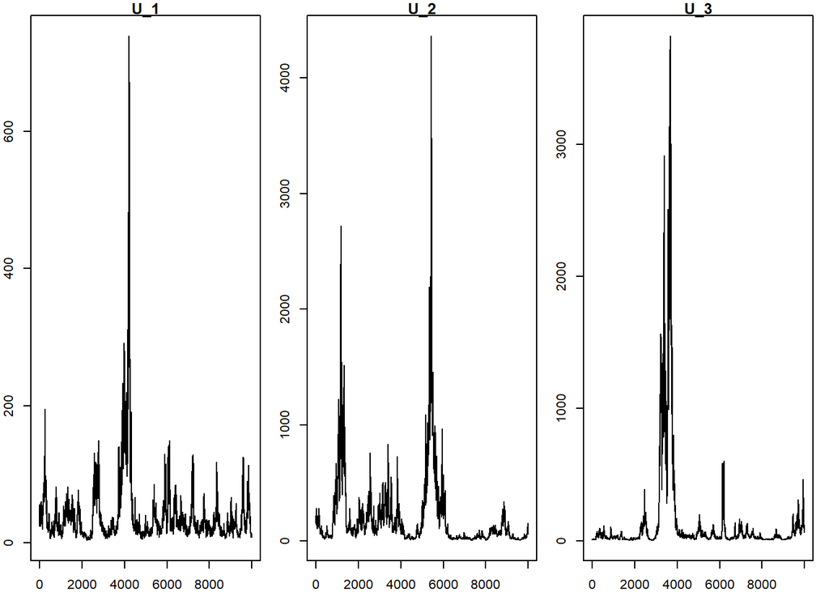

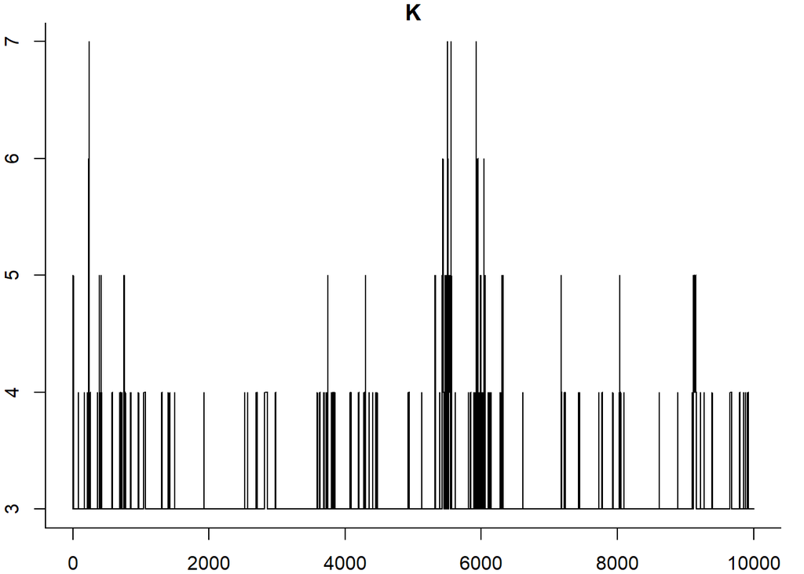

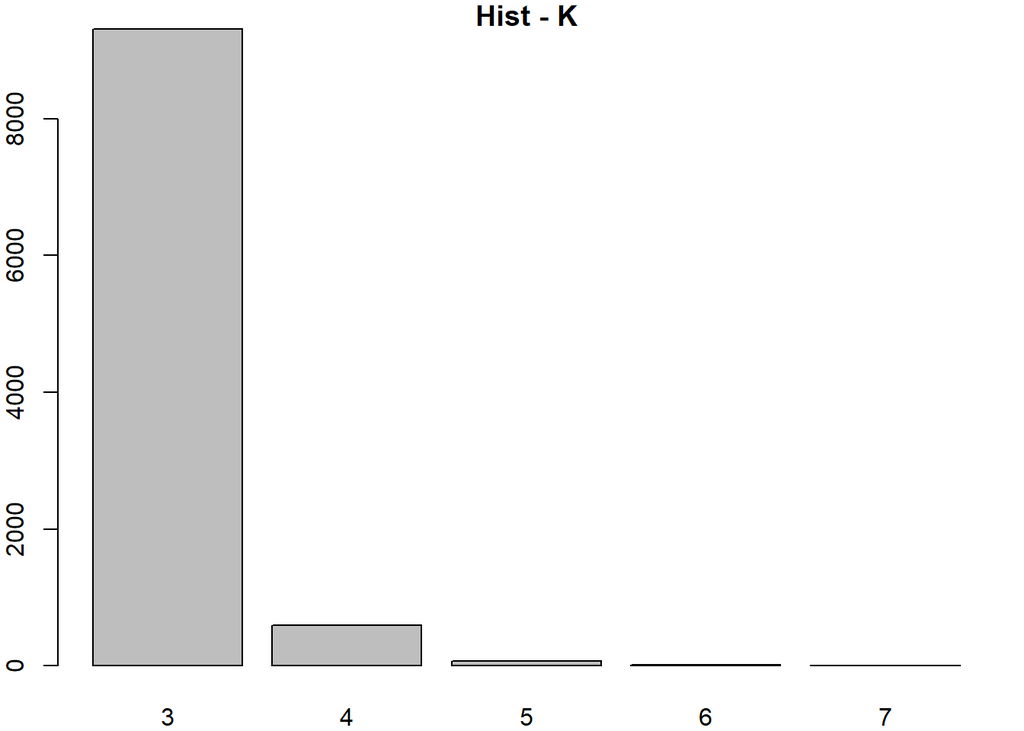

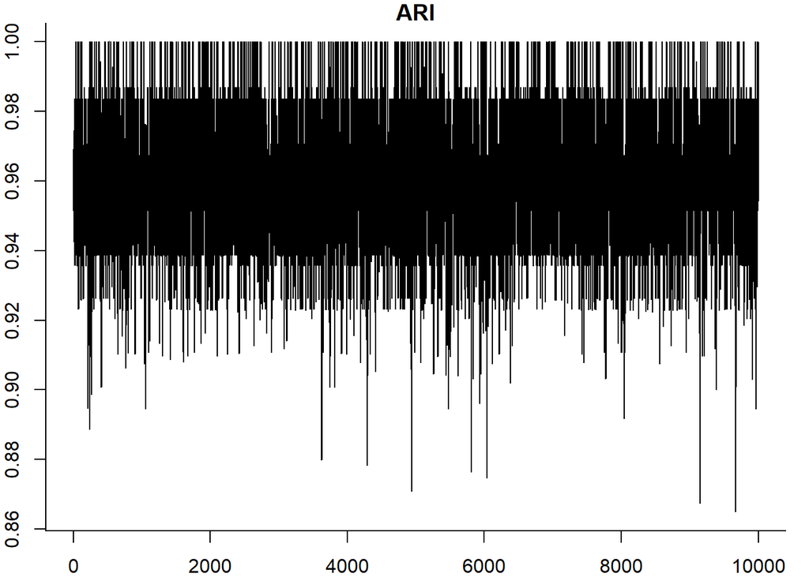

### Clustering

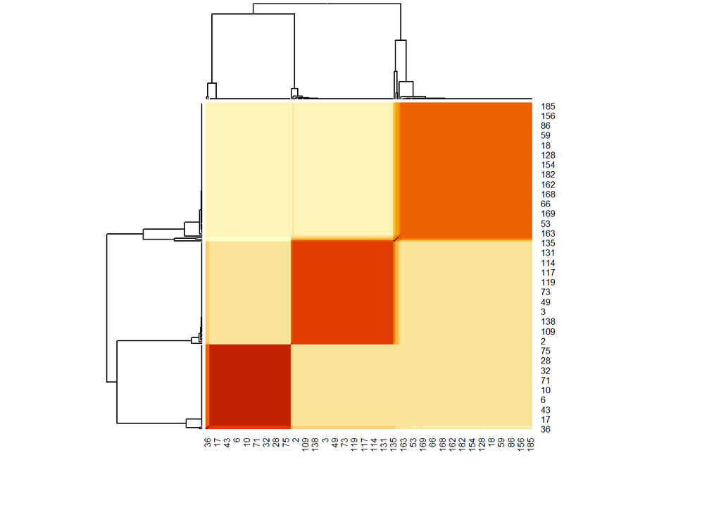

```r
# COMPUTE BINDER LOSS FUNCTION TO SELECT BEST PARTITION

# Get labels for each iterations for each data point
part_matrix <- GDFMM$Partition #GDFMM$Partition is a (n_iter x n_data) matrix

# Compute similarity matrix
sim_matrix <- psm(part_matrix)


heatmap(sim_matrix)
```

```r
binder_sara = minbinder(sim_matrix)
VI_sara = minVI(sim_matrix)

table(binder_sara$cl)
```

```
#>
#>  1  2  3
#> 64 52 84
```

```r
table(VI_sara$cl)
```

```
#>
#>  1  2  3
#> 64 52 84
```

```r
table(real_partition)
```

```
#> real_partition
#>  1  2  3
#> 82 66 52
```

```r
arandi(binder_sara$cl,real_partition)
```

```
#> [1] 0.9674075
```

```r
arandi(VI_sara$cl,real_partition)
```

```
#> [1] 0.9674075
```

### Density estimation

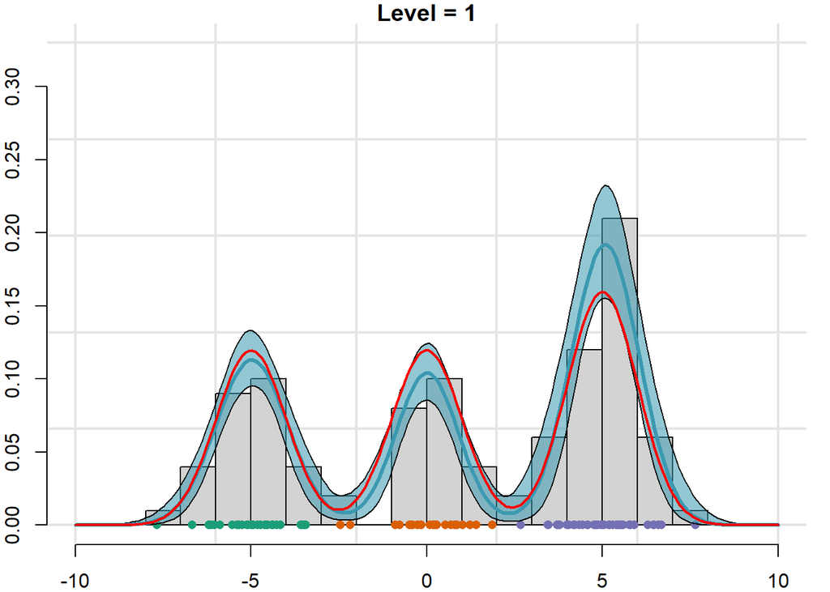

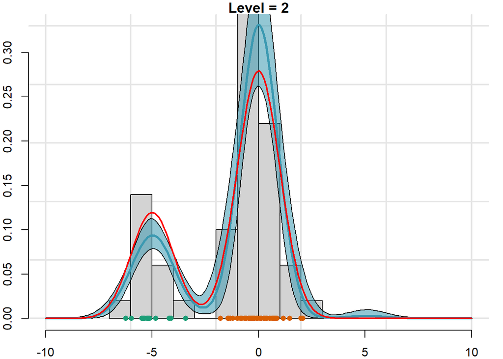

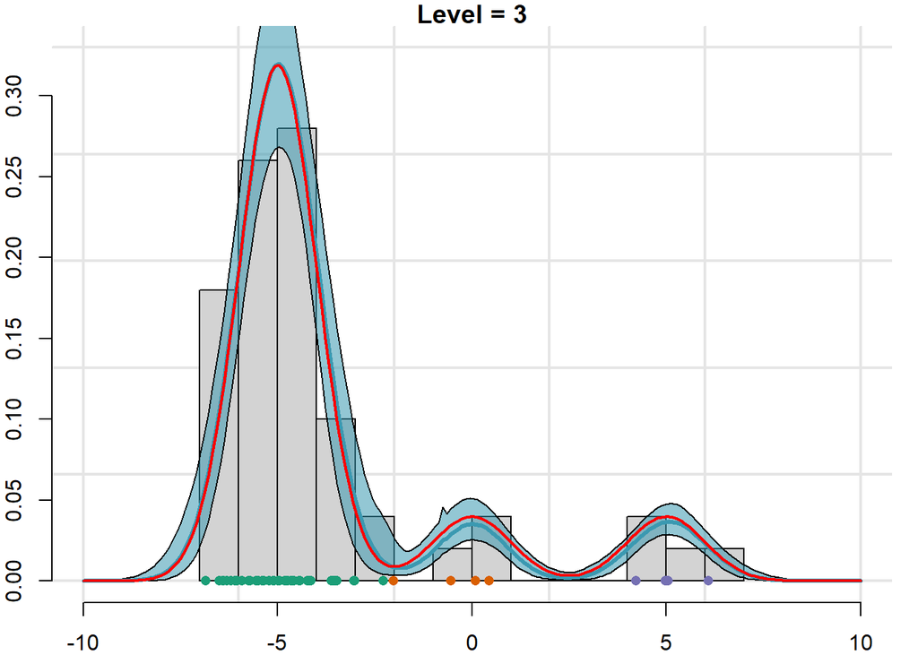

```r
xrange = c(-10,10)
l_grid = 200
grid = seq(xrange[1],xrange[2],length.out = l_grid)
# Predictive in all groups
Pred_all = predictive_marginal_all_groups(grid = grid, fit = GDFMM, burnin = 0, option = option)

# In questo plot sotto colori i pallini secondo il vero cluster.
idx_start = 1
idx_end = n_j[1]


#par(mfrow = c(1,d), mar = c(2,2,1,1))
par(mar = c(2,2,1,1), bty = "l")
for(j in 1:d){

  # set colors
  mycol_cluster = brewer.pal(n=K, name = "Dark2")
  mycol_points  = as.factor(real_partition[idx_start:idx_end])
  levels(mycol_points) = unique(mycol_cluster)
  mycol_points = as.character(mycol_points)


  # frequentist density
  dj = density(data[j,1:n_j[j]])
  yrange = range(Pred_all[[j]][3,]) + 0.001*max(Pred_all[[j]][3,])

  # Trick to add the grid below the plot
  plot.new()
  grid(lty = 1,lwd = 2,col = "gray90" )
  par(new = TRUE)

  # plot
  hist(data[j,1:n_j[j]], freq = F, breaks = n_j[j]/5,
       main = paste0("Level = ",j),
       ylim = c(0,0.33), xlim = xrange,
       ylab = "y-axis", xlab = "x-axis")
  points( x = data[j,1:n_j[j]], y = rep(0,n_j[j]),
          pch = 16, col = mycol_points)
  #lines(dj$x,dj$y, lwd = 3)
  #lines(x = grid, y = Pred_all[[j]][1,], col = "blue", lwd = 2, lty = 2) #0.025
  #lines(x = grid, y = Pred_all[[j]][3,], col = "blue", lwd = 2, lty = 2) #0.975
  polygon( c(grid, rev(grid)),
           c(Pred_all[[j]][1,], rev(Pred_all[[j]][3,])),
           col = ACutils::t_col(mycol[1], percent = 45))
  lines(x = grid, y = Pred_all[[j]][2,], col = mycol[1], lwd = 3) #0.5

  points(grid, dmix(x = grid, w_j = mix_probs[j,], mu_vec = mu, sigma_vec = sd),
         col = "red", lwd = 2, type = "l")

  idx_start = idx_end + 1
    if(j<d){
    idx_end = idx_end + n_j[j+1]
  }
}
```

## Indexes

Compute the co-clustering errors

$$\text{CN} = \frac{1}{n} \sum_{l=1}^n\sum_{k=1}^n \ \lvert \ \pi_{lk} -
\hat{\pi}_{lk} \ \rvert$$
and the co-clustering errors star

$$\text{CN}^* = \frac{1}{n} \sum_{l=1}^n\sum_{k=1}^n \ \lvert \ \pi_{lk} -
\mathbb{I}(\hat{\pi}_{lk}>0.5) \ \rvert$$

where $\hat{\pi}_{lk}$ is the element $l,k$ of the posterior similarity matrix and $\pi_{lk}\in\{0,1\}$ is equal to 1 if $y_l$ and $y_k$ belong to the same cluster, 0 otherwise.

```r
Compute_coclust_error(real_partition, sim_matrix)
```

```
#> $coclust_err
#> [1] 0.01777717
#>
#> $coclust_err_star
#> [1] 0.0145
```

Compute the $L_1$ distance

$$SC = \frac{1}{d}\ \sum_{j=1}^{d} \ \int \ \lvert f(Y_{j,n_j+1}) -
\hat{f}(Y_{j,n_j+1}\mid \mathbf{Y}) \rvert \ dY_{j,n_j+1} \$$

```r
Pred_median = vector("list", length = d)
for(j in 1:d){
  Pred_median[[j]] = Pred_all[[j]][2,]
}

Compute_L1_dist(Pred = Pred_median,
                p_mix = mix_probs, mu = mu, sigma = sd,
                grid = grid)
```

```
#> $L1err_per_level
#> [1] 0.14735024 0.16099275 0.04899916
#>
#> $L1err_average
#> [1] 0.119114
```

Casarin calcola anche mediana e varianza della catena del numero di cluster

```r
median(GDFMM$K)
```

```
#> [1] 3
```

```r
var(GDFMM$K)
```

```
#> [1] 0.1020942
```

# 2 - Tests

## Iperparametri $P_0$

```r
varsig2 = var(as.vector(data), na.rm = T)^2
P0_hyparam = empirical_bayes_normalinvgamma(data = data, varmu = 100, varsig2 = varsig2, correction = 50)
mu0 = P0_hyparam$mu0
k0= P0_hyparam$k0
nu0=P0_hyparam$nu0
sigma0=P0_hyparam$sigma0

c("mu0"=mu0,"k0"=k0,"nu0"=nu0,"sigma0"=sigma0)
```

```
#>          mu0           k0          nu0       sigma0
#> -0.761141824  0.003500266  4.000800000  0.175048309
```

```r
scale = sqrt( (k0 + 1)/(k0) * sigma0 )
mean_marginal = mu0
var_marginal  = nu0/(nu0-2) * scale^2

mean_marginal
```

```
#> [1] -0.7611418
```

```r
var_marginal
```

```
#> [1] 100.35
```

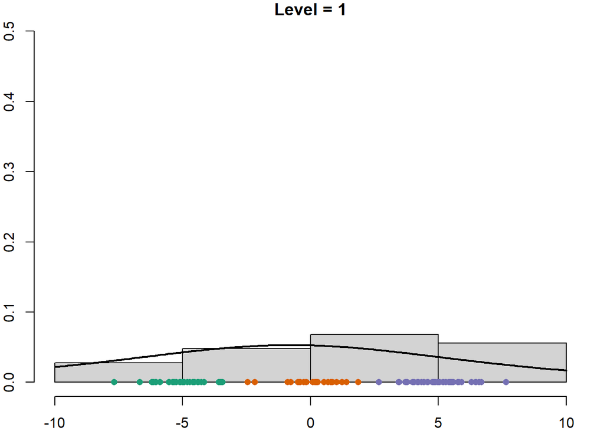

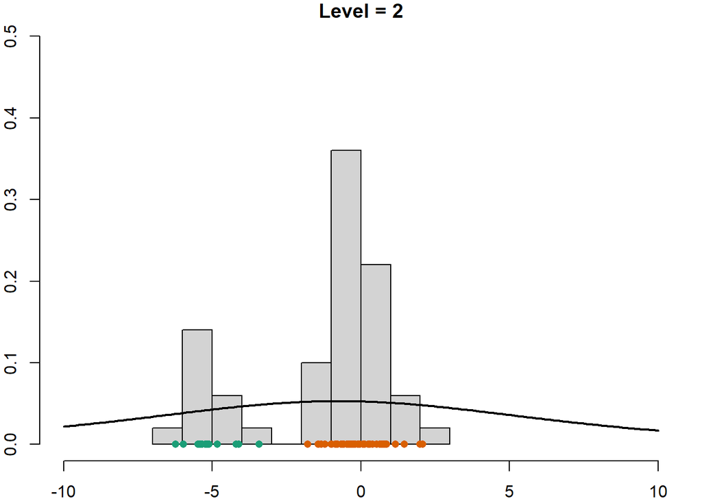

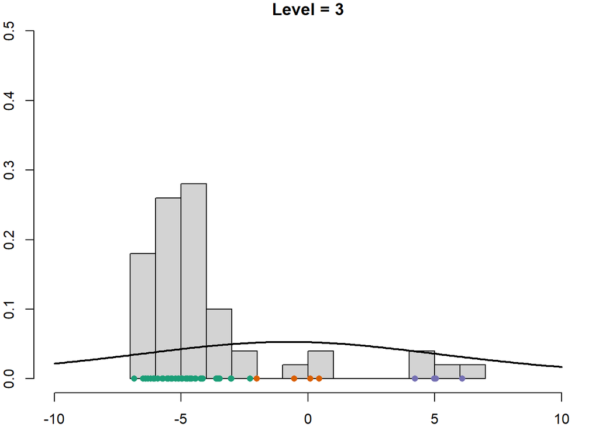

```r
xrange = c(-10,10)
l_grid = 200
grid = seq(xrange[1],xrange[2],length.out = l_grid)
# In questo plot sotto colori i pallini secondo il vero cluster.
idx_start = 1
idx_end = n_j[1]

Prior_grid = GDFMM:::dnct(x = grid, n0 = nu0, mu0 = mu0, gamma0 = scale)

for(j in 1:d){
  mycol_cluster = brewer.pal(n=K, name = "Dark2")
  mycol_points  = as.factor(real_partition[idx_start:idx_end])
  levels(mycol_points) = unique(mycol_cluster)
  mycol_points = as.character(mycol_points)

  par(mar = c(2,2,1,1), bty = "l")
  hist(data[j,1:n_j[j]], freq = F, main = paste0("Level = ",j),
       xlim = xrange, ylim = c(0,0.5),
       nclass = "fd")

  points( x = data[j,1:n_j[j]], y = rep(0,n_j[j]),
          pch = 16, col = mycol_points)
  points(grid, Prior_grid, col = "black", lwd = 2, type = "l")


  idx_start = idx_end + 1
  if(j<d){
    idx_end = idx_end + n_j[j+1]
  }
}
```

### Marginali nei cluster

Fissato il valore degli iperparametri, voglio visualizzare non solo la marginale dei dati ma anche le marginali nei cluster

Calcolo media e varianza nei cluster

```r
counter = 1
data_per_cluster = vector("list", length = K)
log_marginal_prior = vector("list", length = d)
for(j in 1:d){
  log_marginal_prior[[j]] = vector( length = n_j[j])
  for(i in 1:n_j[j]){
    c_ji = real_partition[counter]
    data_per_cluster[[c_ji]] = c(data_per_cluster[[c_ji]], data[j,i])
    log_marginal_prior[[j]][i] = log(ACutils::dnct(data[j,i], n0 = 10, mu0 = 1, gamma0 = sqrt(2)) )
    counter = counter + 1
  }

}
#data_per_cluster
mean_data_per_cluster = unlist(lapply(data_per_cluster, mean))
mean_data_per_cluster
```

```
#> [1] -5.02845382 -0.05042807  5.06602118
```

```r
var_data_per_cluster  = unlist(lapply(data_per_cluster, var))
var_data_per_cluster
```

```
#> [1] 0.9719977 0.9180346 1.0216515
```

```r
ndata_per_cluster = unlist(lapply(data_per_cluster, length))
ndata_per_cluster
```

```
#> [1] 82 66 52
```

```r
#log_marginal_prior
```

```r
dof_post = nu0 + ndata_per_cluster
k0_post  = k0 + ndata_per_cluster
location_post = (k0*mu0 + mean_data_per_cluster*ndata_per_cluster)/(k0 + ndata_per_cluster)
sigma0_post   = 1/dof_post*( (ndata_per_cluster - 1)*var_data_per_cluster +
                              nu0*sigma0 +
                              (k0*ndata_per_cluster)/(k0 + ndata_per_cluster) * (mu0 - mean_data_per_cluster)^2
                           )

scale_post = sqrt( (sigma0_post*(k0_post + 1))/(k0_post)  )

mean_marginal_per_cluster = location_post
var_marginal_per_cluster = scale_post^2 * (dof_post)/(dof_post - 2)

mean_marginal_per_cluster
```

```
#> [1] -5.02827168 -0.05046576  5.06562896
```

```r
var_marginal_per_cluster
```

```
#> [1] 0.9579111 0.9012991 0.9988944
```

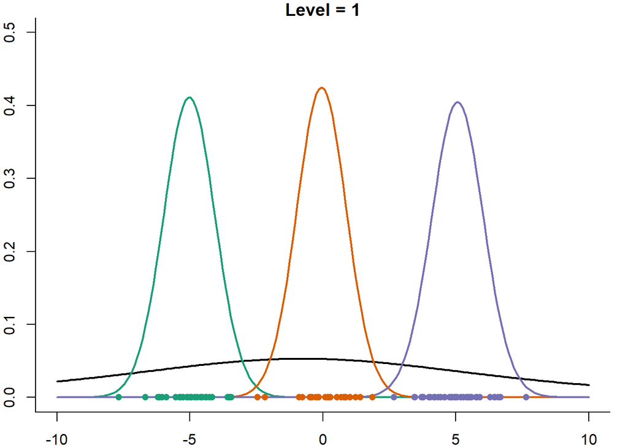

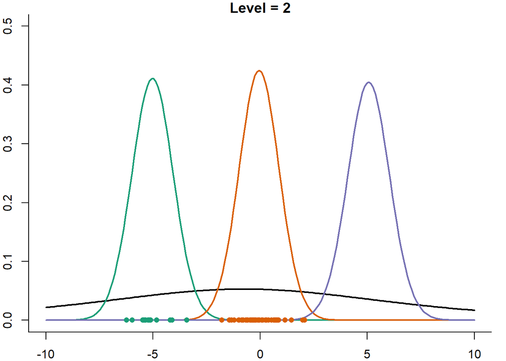

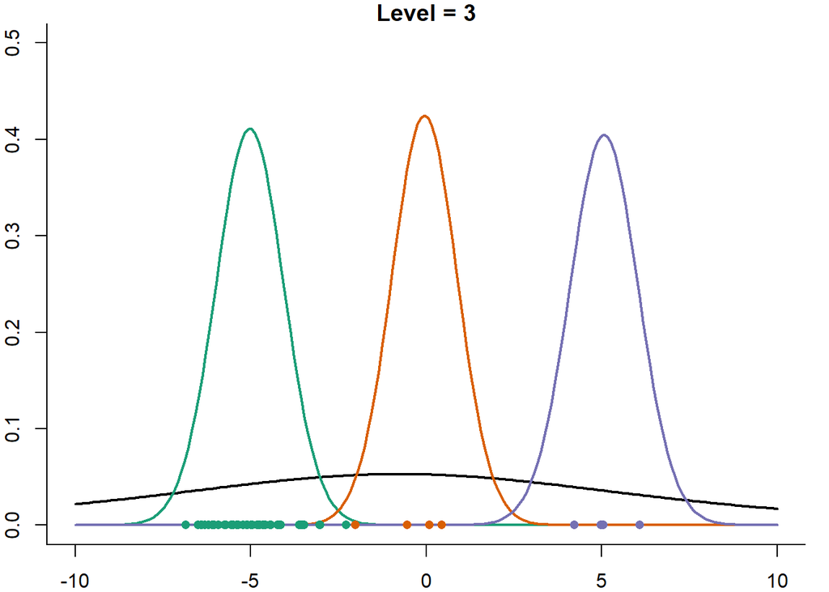

```r
xrange = c(-10,10)
l_grid = 200
grid = seq(xrange[1],xrange[2],length.out = l_grid)
idx_start = 1
idx_end = n_j[1]

Prior_grid = GDFMM:::dnct(x = grid, n0 = nu0, mu0 = mu0, gamma0 = scale)



for(j in 1:d){
  mycol_cluster = brewer.pal(n=K, name = "Dark2")
  mycol_points  = as.factor(real_partition[idx_start:idx_end])
  levels(mycol_points) = unique(mycol_cluster)
  mycol_points = as.character(mycol_points)

  par(mar = c(2,2,1,1), bty = "l")
  plot(grid, Prior_grid, col = "black", lwd = 2, type = "l",
          main = paste0("Level = ",j),
          xlim = xrange, ylim = c(0,0.5))

  for(kk in 1:K){
    Marginal_per_cluster_grid = GDFMM:::dnct(x = grid,
                                         n0 = dof_post[kk],
                                         mu0 = location_post[kk],
                                         gamma0 = scale_post[kk])

    points(grid, Marginal_per_cluster_grid, col = mycol_cluster[kk], lwd = 2, type = "l")

  }
  points( x = data[j,1:n_j[j]], y = rep(0,n_j[j]),
          pch = 16, col = mycol_points )

  idx_start = idx_end + 1
  if(j<d){
    idx_end = idx_end + n_j[j+1]
  }
}
```

## Run

```r
# Run  --------------------------------------------------------------------
niter  <-  10000
burnin <-   6000
thin   <-  1

# tau
a_gamma <-   1; b_gamma  <- 1
a_lambda <- 10; b_lambda <- 2

option = set_options_marginal(
             "mu0" = mu0,"sigma0"= sigma0, "k0"= k0, "nu0"=nu0,
             "Adapt_MH_hyp1"= 0.7,"Adapt_MH_hyp2"= 0.234,
             "sp_mala_U" = 0.01, "sp_mala_gamma"=0.01,
             "gamma0" = 3,"Lambda0" = 10,
             "alpha_gamma"=a_gamma, "beta_gamma"=b_gamma,
             "alpha_lambda"=a_lambda, "beta_lambda"=b_lambda,
             "init_mean_cluster" = NULL,#unlist(mean_data_per_cluster),
             "init_var_cluster" = NULL,#unlist(var_data_per_cluster),
             "UpdateU" = T, "UpdateGamma" = T, "UpdateTau" = T, "UpdateLambda" = T,
             "partition" = real_partition#seq(1,sum(n_j))
        )

# P0 Hyperparameters:
# old set: "mu0" = 0,"sigma0"= 1, "k0"= 1/10, "nu0"=10,
# new set: "mu0" = P0_hyparam$mu0, "k0"= P0_hyparam$k0, "nu0"=P0_hyparam$nu0, "sigma0"= P0_hyparam$sigma0,

# Process parameters
# old set:  "gamma0" = 1,"Lambda0" = 3,
#           "alpha_gamma"=5, "beta_gamma"=0.5, "alpha_lambda"=1, "beta_lambda"=5,


#GDFMM = GDFMM_sampler(data, niter, burnin, thin, seed = 123, option = option)
GDFMM = GDFMM_marginal_sampler(data, niter, burnin, thin, seed = 123, FixPartition = F, option = option)
```

```
#>
#>  Check that provided partition is well formed. It must start from 0 and all values must be contiguous
#> GibbsSamplerMarginal.cpp - Initialization
#> initialize_Partition with non empty partition_vec
#>  (K, Mstar, M) = (3,0,3)
#> DEVO CAMBIARE LA STRUTTURA DEI INPUT DEI DATI COME HA FATTO VEDERE BARTOLUCCI
```

### Chains

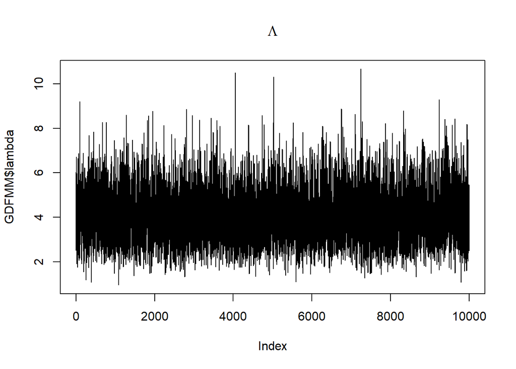

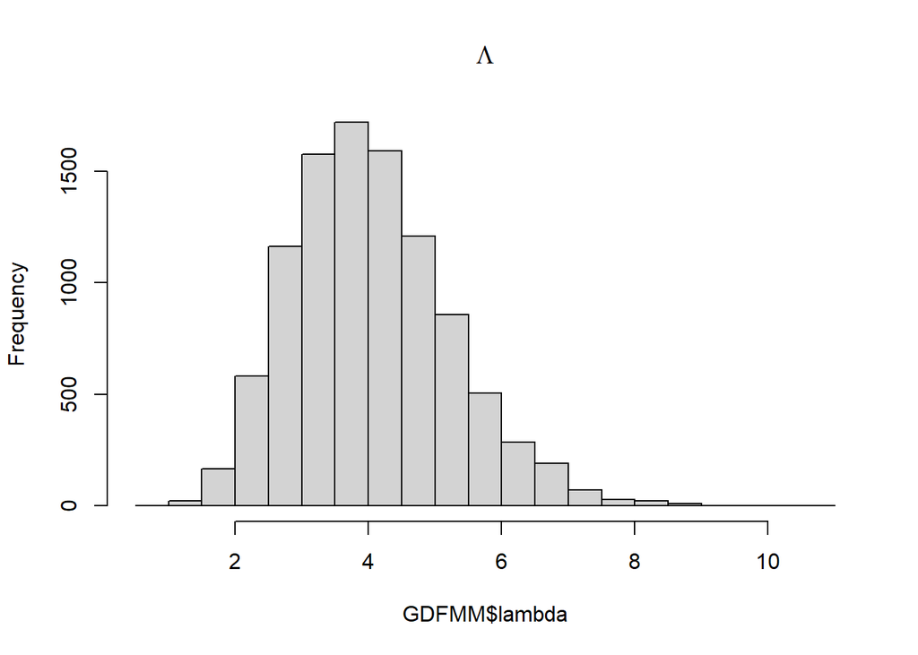

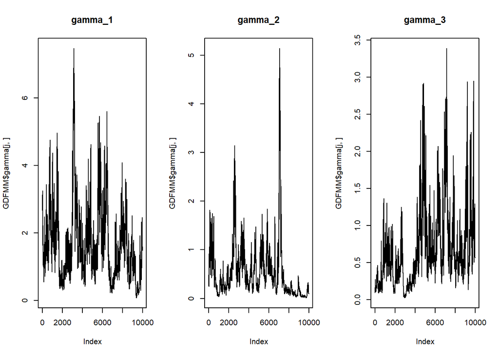

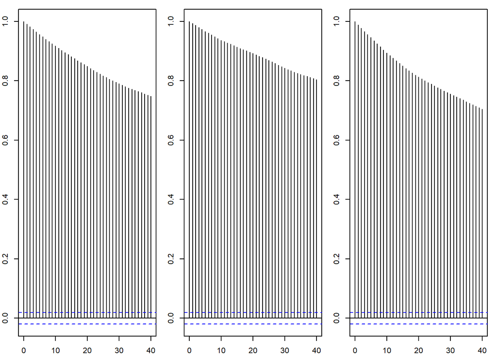

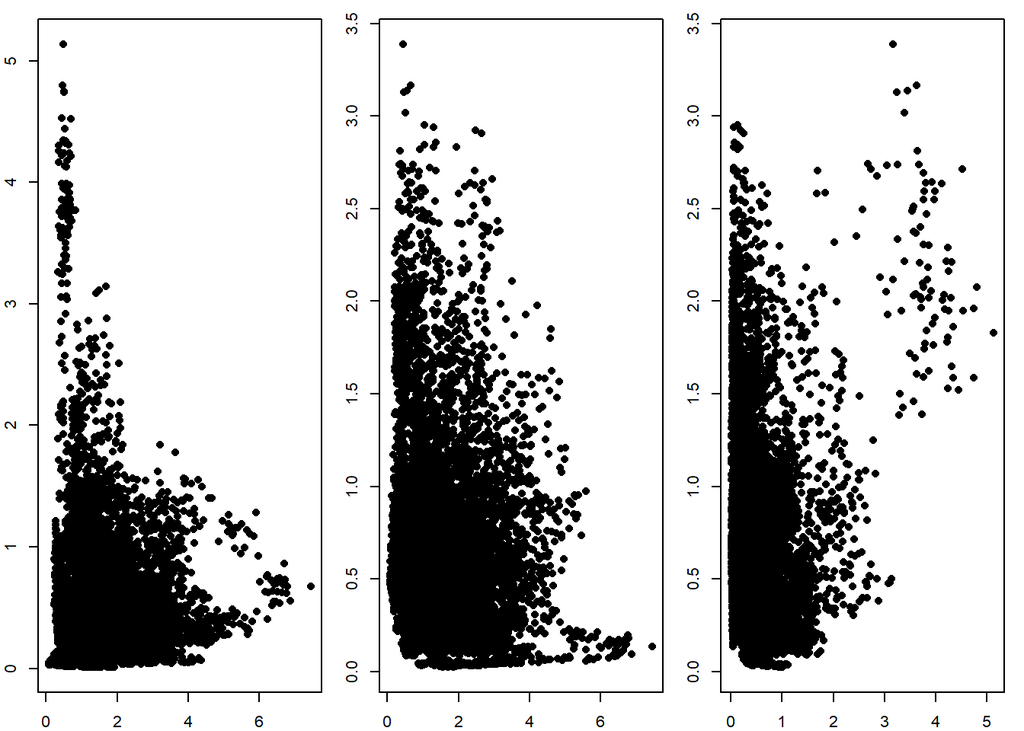